# Joint Headline HICP — 4-component Bayesian VAR with SV, outliers and monthly seasonal dummies

This is the current **production Headline model**.

The model is joint:

[ y_t = \begin{pmatrix} \Delta\log HICP^{Energy}_t\\ \Delta\log HICP^{Food}_t\\ \Delta\log HICP^{NEIG}_t\\ \Delta\log HICP^{Services}_t \end{pmatrix}. ]

All four components are endogenous in one monthly BVAR. This gives a single joint posterior distribution for Energy, Food, NEIG and Services and avoids any cross-model posterior-draw pairing.

The detailed WP374 component models remain **deferred decomposition models** under `notebooks/decomposition/`; they are not required to run this notebook.

### Production choices

- canonical model: **dense BVAR(12)**;
- only lag sensitivity: **dense BVAR(6)**;
- no sparse-lag restriction in the joint model (`active_lags=None`);
- **11 monthly seasonal dummies**, with December as the omitted reference month;
- same validated Energy-suite Bayesian machinery:
  - Minnesota shrinkage;
  - stochastic volatility;
  - model-based outliers;
  - Durbin–Koopman ragged-edge treatment;
  - shared registry/diagnostics.

The four model inputs are aggregate HICP indices. Every endogenous variable therefore uses

[ HICP_t \rightarrow \log(HICP_t) \rightarrow \Delta\log(HICP_t). ]

The monthly dummies are deterministic regressors. They absorb recurring calendar-month effects rather than forcing the VAR lag polynomial to reproduce them as persistent stochastic dynamics.

## 1. Imports and configuration

```python
1+1
```

```
2
```

```python
from __future__ import annotations

import os
import sys
import shutil
import subprocess
import tempfile
from dataclasses import asdict
from pathlib import Path
from typing import Mapping, Sequence

import numpy as np
import pandas as pd
import matplotlib.pyplot as plt
from IPython.display import display


def find_project_root(start: Path) -> Path:
    start = start.resolve()
    for candidate in (start, *start.parents):
        if (candidate / "data").exists() and (candidate / "src").exists():
            return candidate
    raise FileNotFoundError("Could not locate project root containing data/ and src/.")


env_root = os.environ.get("BVAR_PROJECT_ROOT")
PROJECT_ROOT = (
    Path(env_root).expanduser().resolve()
    if env_root
    else find_project_root(Path.cwd())
)

MODEL_DIR = PROJECT_ROOT / "src" / "model"
if str(MODEL_DIR) not in sys.path:
    sys.path.insert(0, str(MODEL_DIR))

from headline_joint_bvar import (
    BASELINE_P,
    SENSITIVITY_P,
    MODEL_ID,
    NATIVE_VARIABLES,
    STATE_VARIABLES,
    STATE_VARIABLE_MAP,
    BVARSVOPriorConfig,
    SamplerConfig,
    aggregate_headline_draws,
    headline_component_forecast_table,
    headline_forecast_table,
    headline_joint_panel_audit,
    headline_joint_spec,
    headline_reconstruction_diagnostics,
    lag_comparison_table,
    load_headline_joint_panel,
    load_headline_joint_weights,
    load_official_headline_total,
    native_to_state_levels,
    state_paths_to_native,
    resolve_headline_reconstruction_start_year,
    reconstruct_headline_history,
    resolve_headline_joint_dataset,
    resolve_headline_joint_weights,
    resolve_headline_official_indices,
)

from headline_joint_plot import (
    plot_headline_aggregate_forecast,
    plot_headline_historical_reconstruction,
    plot_joint_component_forecast_fans,
    plot_joint_model_changes,
    plot_joint_native_levels,
)

from energy_bvar_model import (
    coefficient_posterior_table,
    forecast_bvar_sv_outlier,
    forecast_error_variance_decomposition,
    historical_decomposition,
    impulse_responses,
    mcmc_diagnostics,
    monthly_seasonal_dummies,
    posterior_predictive_statistics,
    residual_diagnostic_table,
    run_energy_bvar,
    stability_diagnostics,
    stationarity_tests,
)

from energy_bvar_plot import (
    plot_chain_acf_grid,
    plot_coefficient_heatmap,
    plot_outlier_probabilities,
    plot_phi_and_outlier_priors,
    plot_posterior_predictive_check,
    plot_posterior_volatility,
    plot_spectral_radius,
    plot_standardized_residuals,
    plot_trace_grid,
    style_numeric_table,
)

try:
    from energy_bvar_io import save_energy_bvar_result
except ImportError:
    save_energy_bvar_result = None


SPEC = headline_joint_spec()

DATA_ROOT = None
VINTAGE = None

QUICK_TEST = False
FORECAST_HORIZON = 18
FORECAST_DRAWS = 250 if QUICK_TEST else 1_000
SAVE_RESULTS = False

# Canonical deterministic seasonality contract.
SEASONAL_REFERENCE_MONTH = 12
SEASONAL_PREFIX = "month"
SEASONAL_EXOG_PRIOR_SCALE = 10.0

# Structural analysis is recursive/Cholesky and therefore ordering-dependent.
RUN_STRUCTURAL_ANALYSIS = True
STRUCTURAL_HORIZON = 24
STRUCTURAL_DRAWS = 150 if QUICK_TEST else 1_000
HD_LAST_OBS = 120

# The only lag sensitivity allowed in the current methodology is BVAR(6) vs BVAR(12).
RUN_BVAR6_SENSITIVITY = False

# Seasonal diagnostics are diagnostic-only: they never alter the canonical model.
RUN_FORMAL_SEASONAL_TESTS = True
SEASONAL_ROOT_DIAGNOSTIC_DRAWS = 300 if QUICK_TEST else 1_000
SEASONAL_SOURCE_LOCALIZATION_DRAWS = 150 if QUICK_TEST else 500
SEASONAL_ROOT_ANGLE_TOLERANCE = np.pi / 24.0  # ±7.5 degrees around a target frequency
SEASONAL_ROOT_MODULUS_THRESHOLDS = (0.90, 0.95, 0.97)
HEGY_MAX_LAG = 12

PRIOR_CONFIG = BVARSVOPriorConfig(
    lambda1=0.20,
    lambda2=0.50,
    lambda3=1.00,
    lambda4=10.0,
    a_prior_var=10.0,
    phi_prior_mean=0.02,
    phi_prior_df=10.0,
    h0_var=4.0,
    outlier_mean_frequency=1.0 / 48.0,
    outlier_prior_observations=120.0,
    outlier_grid_min=2.0,
    outlier_grid_max=20.0,
    outlier_grid_step=1.0,
    ksc_offset_scale=1e-6,
)

SAMPLER_CONFIG = SamplerConfig(
    reps=300 if QUICK_TEST else 6_000,
    burn=150 if QUICK_TEST else 3_000,
    thin=1,
    seed=42,
    max_stability_tries=1_000,
    progress_every=0 if QUICK_TEST else 500,
)


def make_joint_seasonals(index: Sequence[pd.Timestamp]) -> pd.DataFrame:
    """Eleven monthly dummies; December is the omitted reference category."""
    return monthly_seasonal_dummies(
        index,
        reference_month=SEASONAL_REFERENCE_MONTH,
        prefix=SEASONAL_PREFIX,
    )


def _native_conditions_to_state(
    conditions: Mapping[str, float | Sequence[float]] | None,
) -> dict[str, float | np.ndarray] | None:
    if conditions is None:
        return None
    output: dict[str, float | np.ndarray] = {}
    for native_name, values in conditions.items():
        if native_name not in STATE_VARIABLE_MAP:
            raise KeyError(
                f"Unknown native condition variable {native_name!r}; choose from {NATIVE_VARIABLES}."
            )
        arr = np.asarray(values, dtype=float)
        if not np.all(np.isfinite(arr)):
            raise ValueError(f"{native_name}: native conditions must be finite.")
        if np.any(arr <= 0):
            raise ValueError(f"{native_name}: HICP level conditions must be positive.")
        transformed = np.log(arr)
        output[STATE_VARIABLE_MAP[native_name]] = (
            float(transformed) if transformed.ndim == 0 else transformed
        )
    return output


def _component_yoy_paths(
    native_paths: np.ndarray,
    path_dates: pd.DatetimeIndex,
    native_history: pd.DataFrame,
) -> np.ndarray:
    """Compute component YoY paths draw-by-draw using observed pre-path history."""
    draws, _, _ = native_paths.shape
    output = np.full_like(native_paths, np.nan, dtype=float)
    pos = {pd.Timestamp(date): i for i, date in enumerate(path_dates)}
    history = native_history[NATIVE_VARIABLES].copy().sort_index()
    history.index = pd.DatetimeIndex(history.index).to_period("M").to_timestamp(how="start")
```

```python
    for t, date in enumerate(path_dates):
        lag_date = pd.Timestamp(date) - pd.DateOffset(months=12)
        for j, name in enumerate(NATIVE_VARIABLES):
            if lag_date in pos:
                denominator = native_paths[:, pos[lag_date], j]
            else:
                if lag_date not in history.index or pd.isna(history.loc[lag_date, name]):
                    continue
                denominator = np.full(draws, float(history.loc[lag_date, name]), dtype=float)
            output[:, t, j] = 100.0 * (native_paths[:, t, j] / denominator - 1.0)
    return output


def run_headline_joint_bvar(
    native_levels: pd.DataFrame,
    *,
    vintage: str,
    p: int = BASELINE_P,
    prior_config: BVARSVOPriorConfig | None = None,
    sampler_config: SamplerConfig | None = None,
    code_version: str = "headline-joint-seasonal-v1",
) -> dict:
    """Notebook production wrapper: dense joint BVAR + 11 monthly dummies."""
    if int(p) not in (SENSITIVITY_P, BASELINE_P):
        raise ValueError(f"Headline joint policy allows only p={SENSITIVITY_P} or p={BASELINE_P}.")
    state = native_to_state_levels(native_levels)
    seasonals = make_joint_seasonals(state.index)
    prior_config = BVARSVOPriorConfig() if prior_config is None else prior_config
    sampler_config = SamplerConfig() if sampler_config is None else sampler_config

    result = run_energy_bvar(
        levels=state,
        model_id=MODEL_ID,
        vintage=str(vintage),
        p=int(p),
        variables=STATE_VARIABLES,
        frequency="monthly",
        exog=seasonals,
        exog_prior_scale=SEASONAL_EXOG_PRIOR_SCALE,
        prior_config=prior_config,
        sampler_config=sampler_config,
        active_lags=None,
        code_version=code_version,
    )
    result["headline_joint_context"] = {
        "native_variables": list(NATIVE_VARIABLES),
        "state_variables": list(STATE_VARIABLES),
        "state_variable_map": dict(STATE_VARIABLE_MAP),
        "native_levels": native_levels[NATIVE_VARIABLES].copy(),
        "seasonal_reference_month": SEASONAL_REFERENCE_MONTH,
    }
    result["metadata"].update(
        {
            "suite": "headline",
            "component": "headline_joint",
            "model_class": f"dense BVAR({int(p)}) + monthly seasonal dummies",
            "native_variables": list(NATIVE_VARIABLES),
            "state_variables": list(STATE_VARIABLES),
            "state_variable_map": dict(STATE_VARIABLE_MAP),
            "transform_map": {name: "logdiff" for name in NATIVE_VARIABLES},
            "active_lags": None,
            "seasonal_dummies": True,
            "seasonal_reference_month": int(SEASONAL_REFERENCE_MONTH),
            "seasonal_exog_names": list(seasonals.columns),
            "lag_policy": "canonical dense BVAR(12); only sensitivity is dense BVAR(6)",
            "headline_joint_notebook_version": "2026-08-12-seasonal-v1",
        }
    )
    return result


def forecast_headline_joint_bvar(
    result: Mapping,
    *,
    native_levels: pd.DataFrame | None = None,
    H: int = 18,
    native_level_conditions: Mapping[str, float | Sequence[float]] | None = None,
    n_draws: int | None = None,
    simulate_future_outliers: bool = True,
    seed: int = 123,
) -> dict[str, object]:
    """Forecast wrapper that extends the fitted monthly dummy design into the future."""
    if native_levels is None:
        native_levels = result.get("headline_joint_context", {}).get("native_levels")
    if not isinstance(native_levels, pd.DataFrame):
        raise ValueError("native_levels is required for the Headline forecast wrapper.")

    last_date = pd.Timestamp(result["prep"]["last_calendar_date"])
    future_dates = pd.date_range(
        last_date + pd.offsets.MonthBegin(1),
        periods=int(H),
        freq="MS",
        name="date",
    )
    future_exog = make_joint_seasonals(future_dates)
    fitted_names = list(result["prep"].get("exog_names", []))
    if list(future_exog.columns) != fitted_names:
        raise ValueError(
            "Future monthly-dummy columns do not match the fitted exogenous contract: "
            f"future={list(future_exog.columns)}, fitted={fitted_names}."
        )

    state_forecast = forecast_bvar_sv_outlier(
        result,
        H=int(H),
        level_conditions=_native_conditions_to_state(native_level_conditions),
        future_exog=future_exog,
        n_draws=n_draws,
        simulate_future_outliers=bool(simulate_future_outliers),
        seed=int(seed),
    )
    if list(state_forecast["variables"]) != STATE_VARIABLES:
        raise ValueError(
            f"State-variable ordering changed: expected {STATE_VARIABLES}, "
            f"found {state_forecast['variables']}."
        )

    native_paths = state_paths_to_native(state_forecast["level_paths"])
    path_dates = pd.DatetimeIndex(state_forecast["path_dates"], name="date")
    component_yoy = _component_yoy_paths(native_paths, path_dates, native_levels)
    tail = int(state_forecast["tail_length"])

    output = dict(state_forecast)
    output.update(
        {
            "component": MODEL_ID,
            "component_label": "Headline components joint BVAR",
            "native_variables": list(NATIVE_VARIABLES),
            "state_variables": list(STATE_VARIABLES),
            "native_level_paths": native_paths,
            "future_native_level_paths": native_paths[:, tail:],
            "component_yoy_paths": component_yoy,
            "future_component_yoy_paths": component_yoy[:, tail:],
            "native_level_conditions": (
                None if native_level_conditions is None else dict(native_level_conditions)
            ),
            "future_seasonal_exog": future_exog,
            "forecast_contract_version": "headline_joint_seasonal_v1",
        }
    )
    return output


def posterior_draw_subset(result: Mapping, n_draws: int | None) -> dict:
    """Deterministically thin posterior arrays for expensive structural diagnostics only."""
    total = int(result["n_draws"])
    if n_draws is None or int(n_draws) >= total:
        return dict(result)
    keep = int(n_draws)
    if keep < 1:
        raise ValueError("n_draws must be positive.")
    idx = np.linspace(0, total - 1, keep, dtype=int)
    out = dict(result)
    draw_keys = [
        "B", "A", "log_variance", "phi", "outlier_scales",
        "outlier_indicators", "outlier_probabilities",
        "posterior_outlier_probability_draws", "spectral_radius",
        "log_likelihood", "completed_differences_draws",
        "missing_level_draws", "last_companion_state_draws",
    ]
    for key in draw_keys:
        if key in result:
            arr = np.asarray(result[key])
            if arr.ndim >= 1 and arr.shape[0] == total:
                out[key] = arr[idx]
    out["n_draws"] = len(idx)
    out["structural_draw_indices_from_full_posterior"] = idx
    return out
```

```python
SPEC.update(
    {
        "seasonal_dummies": True,
        "seasonal_reference_month": SEASONAL_REFERENCE_MONTH,
        "seasonal_exog_prior_scale": SEASONAL_EXOG_PRIOR_SCALE,
    }
)

print("PROJECT_ROOT:", PROJECT_ROOT)
print("Canonical model:", f"dense BVAR({BASELINE_P}) + 11 monthly dummies")
print("Only lag sensitivity:", f"dense BVAR({SENSITIVITY_P}) + same dummies")
print("Seasonal reference month:", SEASONAL_REFERENCE_MONTH, "(December)")
print("Variable ordering:", NATIVE_VARIABLES)
```

```
PROJECT_ROOT: C:\Users\kelyan.gane\Project\Python\Bayesian_model\bvar-energy
Canonical model: dense BVAR(12) + 11 monthly dummies
Only lag sensitivity: dense BVAR(6) + same dummies
Seasonal reference month: 12 (December)
Variable ordering: ['hicp_energy', 'hicp_food', 'hicp_neig', 'hicp_services']
```

### Variable ordering

The canonical order is fixed as:

```
1. HICP Energy
2. HICP Food
3. HICP NEIG
4. HICP Services
```

The BVAR forecast itself is the primary object. Any future recursive structural interpretation must explicitly acknowledge this ordering; this notebook does **not** label the recursive innovations as economic structural shocks.

## 2. Resolve the official processed vintage

```python
DATASET_PATH = resolve_headline_joint_dataset(
    PROJECT_ROOT,
    vintage=VINTAGE,
    data_root=DATA_ROOT,
)
VINTAGE_USED = DATASET_PATH.parent.name

WEIGHTS_PATH = resolve_headline_joint_weights(
    PROJECT_ROOT,
    vintage=VINTAGE_USED,
    data_root=DATA_ROOT,
)
OFFICIAL_INDICES_PATH = resolve_headline_official_indices(
    PROJECT_ROOT,
    vintage=VINTAGE_USED,
    data_root=DATA_ROOT,
)

print("Vintage:", VINTAGE_USED)
print("Joint dataset:", DATASET_PATH)
print("Annual weights:", WEIGHTS_PATH)
print("Official total/reference indices:", OFFICIAL_INDICES_PATH)
```

```
Vintage: 20260811_headline_joint
Joint dataset: C:\Users\kelyan.gane\Project\Python\Bayesian_model\bvar-energy\data\processed\20260811_headline_joint\headline_joint_monthly.csv
Annual weights: C:\Users\kelyan.gane\Project\Python\Bayesian_model\bvar-energy\data\processed\20260811_headline_joint\headline_joint_weights_annual.csv
Official total/reference indices: C:\Users\kelyan.gane\Project\Python\Bayesian_model\bvar-energy\data\processed\20260811_headline_joint\headline_hicp_indices_monthly.csv
```

## 3. Load and audit native HICP inputs

```python
native_levels = load_headline_joint_panel(DATASET_PATH)
weights = load_headline_joint_weights(WEIGHTS_PATH)
official_total = load_official_headline_total(OFFICIAL_INDICES_PATH)

display(headline_joint_panel_audit(native_levels))

complete_weights = weights.dropna(how="any")
weight_check = pd.DataFrame(
    {
        "component_sum": complete_weights.sum(axis=1),
        "sum_minus_1000": complete_weights.sum(axis=1) - 1000.0,
    }
)
display(weight_check.tail(10))
```

| series | first_observed | last_observed | observations | leading_missing | interior_missing | trailing_missing | min | max |
| --- | --- | --- | --- | --- | --- | --- | --- | --- |
| hicp_energy | 1996-01-01 | 2026-07-01 | 367 | 12 | 0 | 0 | 35.84 | 117.62 |
| hicp_food | 1995-01-01 | 2026-06-01 | 378 | 0 | 0 | 1 | 48.63 | 101.43 |
| hicp_neig | 1999-12-01 | 2026-07-01 | 320 | 59 | 0 | 0 | 78.22 | 101.78 |
| hicp_services | 1999-12-01 | 2026-07-01 | 320 | 59 | 0 | 0 | 57.68 | 104.81 |

| year | component_sum | sum_minus_1000 |
| --- | --- | --- |
| 2017 | 1000.00 | 0.00 |
| 2018 | 1000.00 | 0.00 |
| 2019 | 1000.01 | 0.01 |
| 2020 | 999.99 | -0.01 |
| 2021 | 1000.00 | 0.00 |
| 2022 | 1000.00 | 0.00 |
| 2023 | 1000.00 | 0.00 |
| 2024 | 1000.01 | 0.01 |
| 2025 | 1000.00 | 0.00 |
| 2026 | 1000.00 | 0.00 |

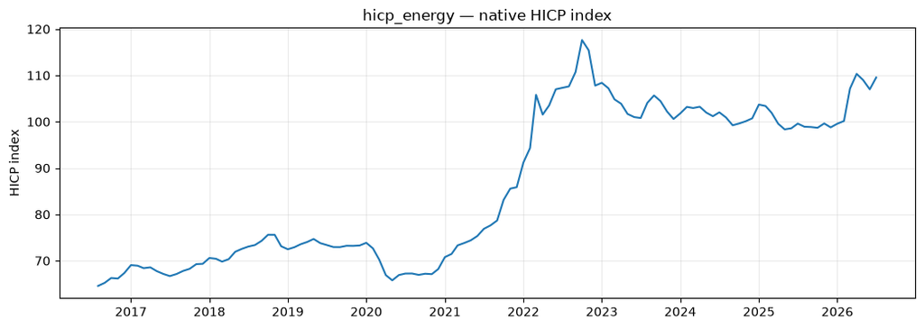

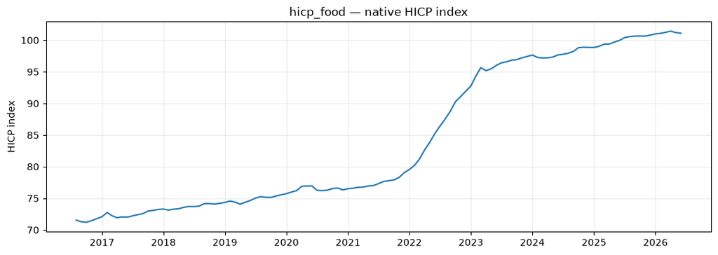

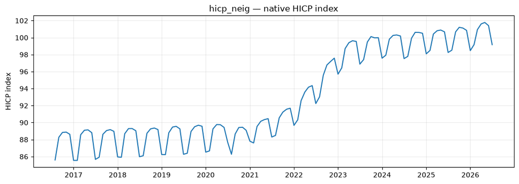

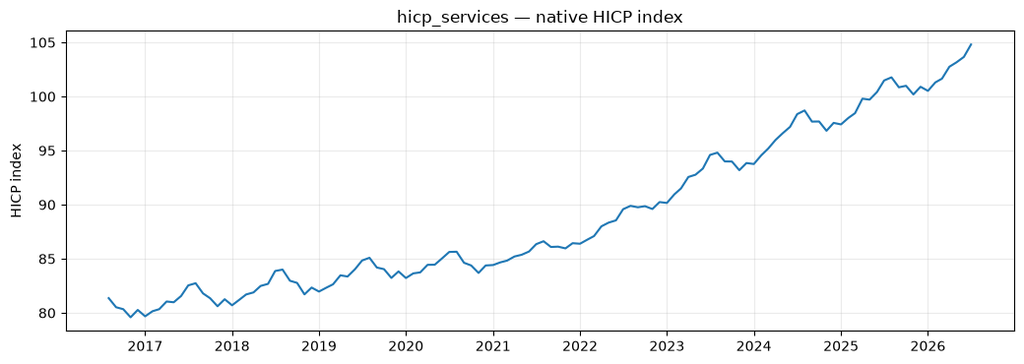

```python
figures = plot_joint_native_levels(native_levels, last_obs=120)
for fig in figures.values():
    display(fig)
    plt.close(fig)
```

The builder keeps all four variables in **native index levels**. No log transformation or differencing is hidden in the Excel/data-construction layer.

## 4. Common model-space transformation and deterministic seasonality

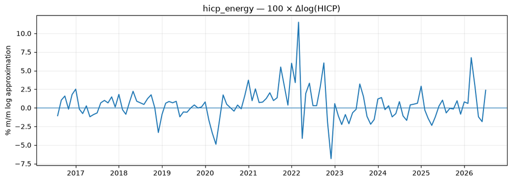

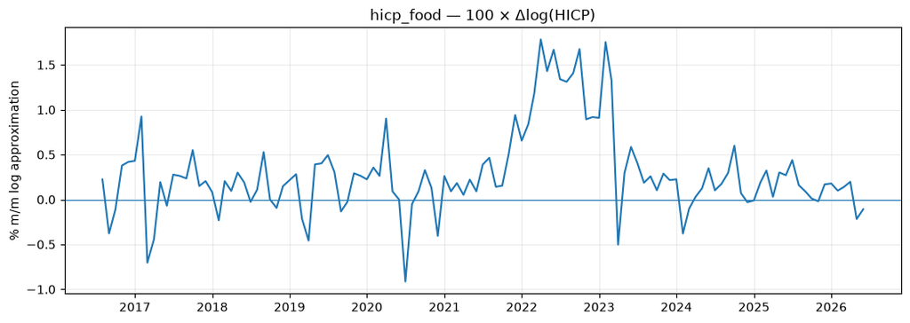

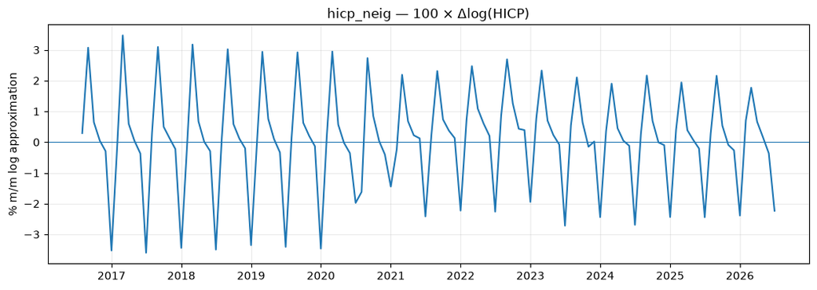

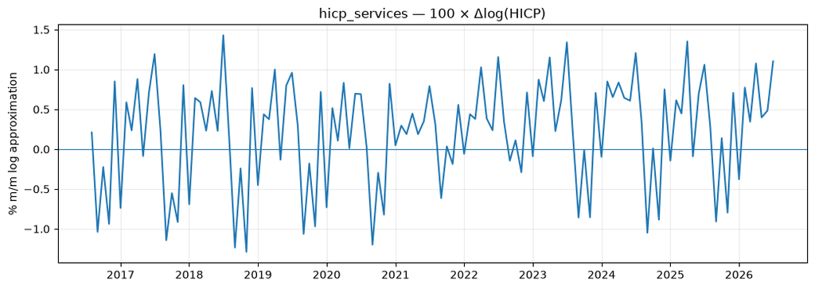

```
State variables: ['state__hicp_energy', 'state__hicp_food', 'state__hicp_neig', 'state__hicp_services']
Seasonal regressors: ['month_01', 'month_02', 'month_03', 'month_04', 'month_05', 'month_06', 'month_07', 'month_08', 'month_09', 'month_10', 'month_11']
Reference month: December
Dummy matrix shape: (379, 11)
```

| date | month_01 | month_02 | month_03 | month_04 | month_05 | month_06 | month_07 | month_08 | month_09 | month_10 | month_11 |
| --- | --- | --- | --- | --- | --- | --- | --- | --- | --- | --- | --- |
| 2025-06-01 | 0.0 | 0.0 | 0.0 | 0.0 | 0.0 | 1.0 | 0.0 | 0.0 | 0.0 | 0.0 | 0.0 |
| 2025-07-01 | 0.0 | 0.0 | 0.0 | 0.0 | 0.0 | 0.0 | 1.0 | 0.0 | 0.0 | 0.0 | 0.0 |
| 2025-08-01 | 0.0 | 0.0 | 0.0 | 0.0 | 0.0 | 0.0 | 0.0 | 1.0 | 0.0 | 0.0 | 0.0 |
| 2025-09-01 | 0.0 | 0.0 | 0.0 | 0.0 | 0.0 | 0.0 | 0.0 | 0.0 | 1.0 | 0.0 | 0.0 |
| 2025-10-01 | 0.0 | 0.0 | 0.0 | 0.0 | 0.0 | 0.0 | 0.0 | 0.0 | 0.0 | 1.0 | 0.0 |
| 2025-11-01 | 0.0 | 0.0 | 0.0 | 0.0 | 0.0 | 0.0 | 0.0 | 0.0 | 0.0 | 0.0 | 1.0 |
| 2025-12-01 | 0.0 | 0.0 | 0.0 | 0.0 | 0.0 | 0.0 | 0.0 | 0.0 | 0.0 | 0.0 | 0.0 |
| 2026-01-01 | 1.0 | 0.0 | 0.0 | 0.0 | 0.0 | 0.0 | 0.0 | 0.0 | 0.0 | 0.0 | 0.0 |
| 2026-02-01 | 0.0 | 1.0 | 0.0 | 0.0 | 0.0 | 0.0 | 0.0 | 0.0 | 0.0 | 0.0 | 0.0 |
| 2026-03-01 | 0.0 | 0.0 | 1.0 | 0.0 | 0.0 | 0.0 | 0.0 | 0.0 | 0.0 | 0.0 | 0.0 |
| 2026-04-01 | 0.0 | 0.0 | 0.0 | 1.0 | 0.0 | 0.0 | 0.0 | 0.0 | 0.0 | 0.0 | 0.0 |
| 2026-05-01 | 0.0 | 0.0 | 0.0 | 0.0 | 1.0 | 0.0 | 0.0 | 0.0 | 0.0 | 0.0 | 0.0 |
| 2026-06-01 | 0.0 | 0.0 | 0.0 | 0.0 | 0.0 | 1.0 | 0.0 | 0.0 | 0.0 | 0.0 | 0.0 |
| 2026-07-01 | 0.0 | 0.0 | 0.0 | 0.0 | 0.0 | 0.0 | 1.0 | 0.0 | 0.0 | 0.0 | 0.0 |

```python
state_levels = native_to_state_levels(native_levels)
model_changes = 100.0 * state_levels.diff()
seasonal_exog = make_joint_seasonals(state_levels.index)

figures = plot_joint_model_changes(native_levels, last_obs=120)
for fig in figures.values():
    display(fig)
    plt.close(fig)

print("State variables:", list(state_levels.columns))
print("Seasonal regressors:", list(seasonal_exog.columns))
print("Reference month: December")
print("Dummy matrix shape:", seasonal_exog.shape)
display(seasonal_exog.tail(14))

assert seasonal_exog.shape[1] == 11
assert not seasonal_exog.isna().any().any()
assert seasonal_exog.loc[seasonal_exog.index.month == 12].sum(axis=1).eq(0.0).all()
```

Every endogenous equation is estimated on monthly log changes:

[ \Delta\log HICP_t = \log(HICP_t)-\log(HICP_{t-1}). ]

The BVAR also contains 11 deterministic calendar-month indicators. December is the omitted category because the model already contains a constant. The dummies are known over the full historical and forecast calendar and are passed through the engine's `exog` / `future_exog` contract.

This is important for the NSA HICP inputs: recurring monthly effects are represented as deterministic seasonality instead of being forced into near-unit complex roots of the stochastic VAR lag polynomial. The dummies do **not** enter the companion matrix used for stability, IRFs or FEVD; in the historical decomposition they enter the deterministic/base contribution.